# Spatial data, mapping with Leaflet

Dan Warren

1/4/2019

```r
library(raster)
library(rgeos)
```

```r
library(ggplot2)
library(viridis)
library(sp)
library(plotly)
library(leaflet)
library(maptools)
library(mapview)
library(rgbif)
```

# Retrieving spatial data and basic plots

In this lesson, we are going to explore spatial data. These are the three main spatial data types. There’s a lot to learn here, and we’re just just going to do the bits that are going to be most crucial for the coming lessons. For a more thorough tutorial I highly recommend the tutorials listed by Francisco Rodriguez-Sanchez here:

https://github.com/Pakillo/GISwithR/

And also Robert Hijmans’ online texts at

http://www.rspatial.org/

Although a few of the examples don’t seem to be working now due to updates with the required packages (i.e., changes in syntax in newer versions).

First we’re going to get a polygon for Spain.

Oddly enough, it’s the “raster” package that makes this super easy. The getData function hooks into several online databases of spatial information, including the Global Administrative areas.

In my case, I have to call getData using raster::getData so that it knows I want the “getData” function from package “raster”. This is because another package called “nlme” also has a getData function, and R might call it by default instead. This may not be necessary for you.

```r
spain <- raster::getData('GADM', country='ESP', level=1)
```

That shapefile is at a VERY fine resolution and slow to draw, because the level of detail is very, very high! Let’s simplify it. We’ll use a function called gSimplify. In gSimplify, the “tol” parameter controls how far the resulting curve is allowed to diverge from the original. Smaller values = more complex curves = larger and slower objects in memory. Play around with the tol value and see what happens!

```r
spain <- gSimplify(spain, tol=0.01, topologyPreserve=TRUE)
```

Now let’s plot it using R’s base graphics.

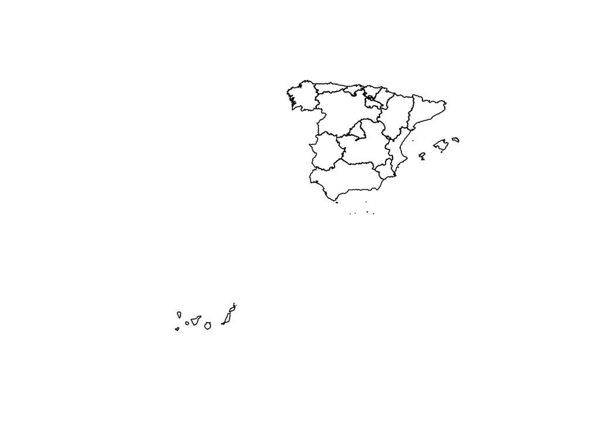

```r
plot(spain)
```

Base plots leave a lot to be desired, though, so we’ll use ggplot to make a map.

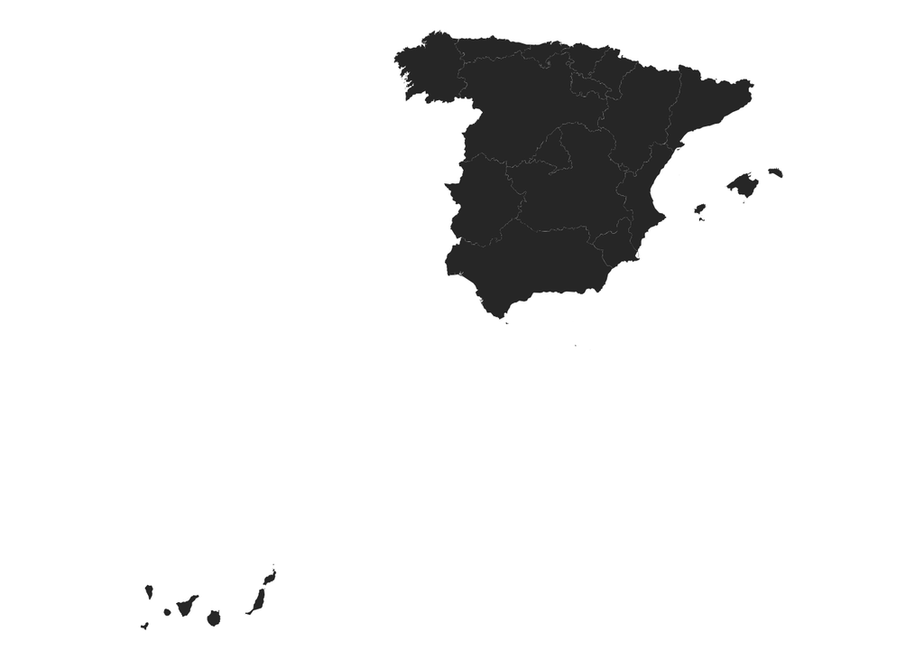

```r
ggplot() + geom_polygon(data = spain, aes(x=long, y = lat, group = group)) +
  coord_fixed(1.3) + theme_void()
```

Adding some points

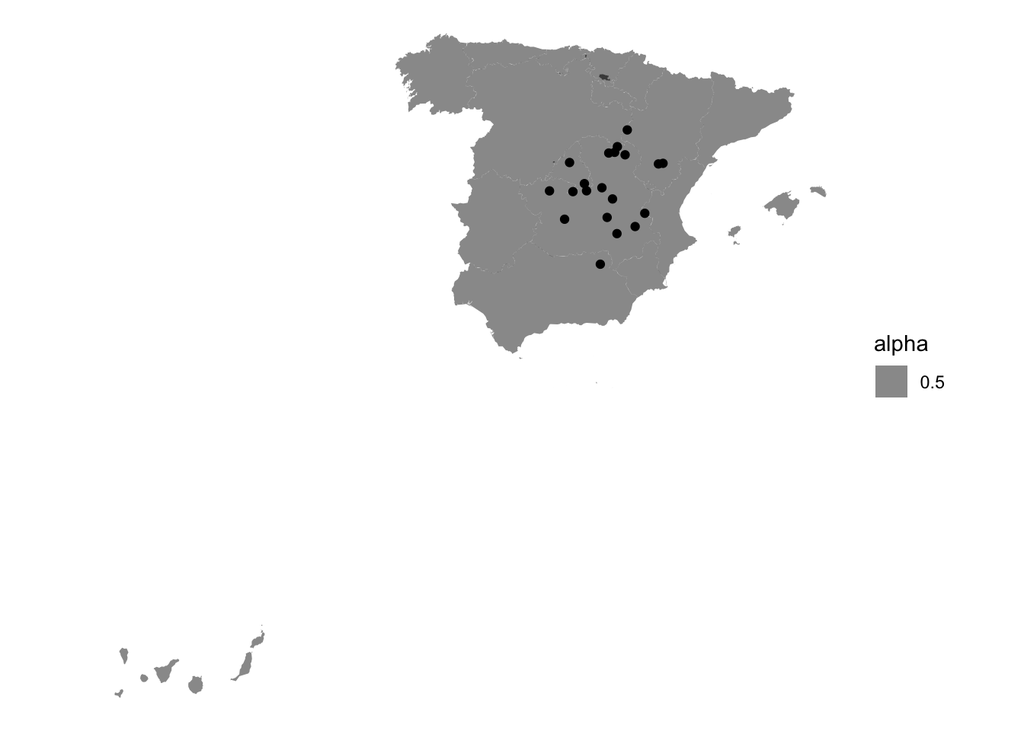

```r
x <- rnorm(n = 20, mean = -3, sd = 1)
y <- rnorm(n = 20, mean = 40, sd = 1)
pts <- as.data.frame(cbind(x, y))

ggplot() + geom_polygon(data = spain, aes(x=long, y = lat, group = group, alpha = 0.5)) +
  coord_fixed(1.3) + geom_point(data = pts, aes(x = x, y = y)) +theme_void()
```

And to round it all out, we’ll get some environmental data in a raster. You can use the same getData function to get Worldclim data, which people use for SDMs and other stuff.

First we’ll plot it with base graphics.

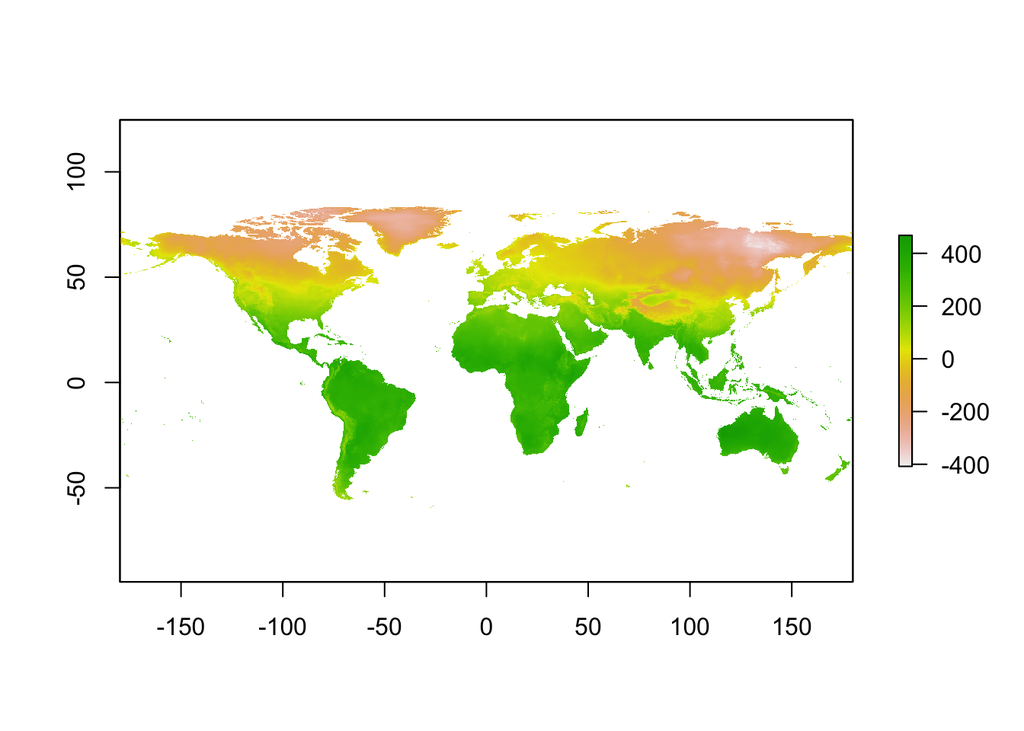

```r
env <- raster::getData("CMIP5", var = "tmax", res = 2.5, model = "AC", year = 70, rcp = 85)
plot(env[[1]])
```

That’s the whole world, though. We can clip that down using our Spain polygon,

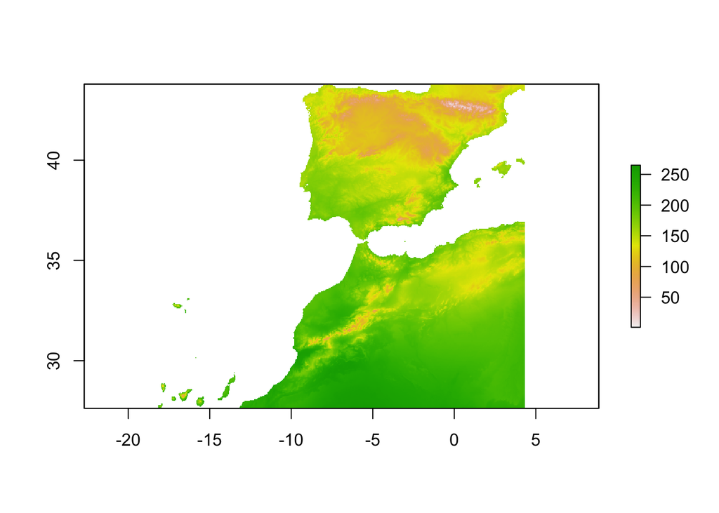

```r
env.poly <- crop(x = env, spain)
plot(env.poly[[1]])
```

Notice what it did there? It didn’t actually give us the portion covered by our polygons; it clipped the raster to the *extent* of that polygon layer.

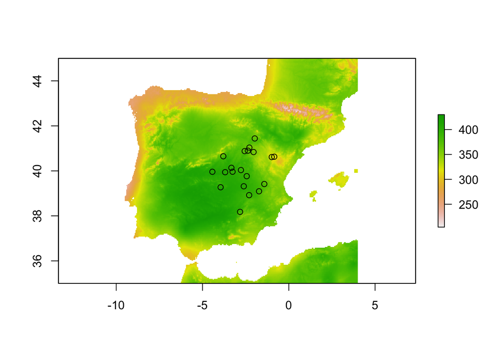

```r
spain.extent <- extent(-10, 4, 35, 45)
env <- crop(x = env, y = spain.extent)
tmax <- max(env)

plot(tmax)
points(pts)
```

And now with ggplot. The trick to plotting raster with ggplot is that you need to convert them to data frames first. The xy = TRUE argument tells it to record the latitude and longitude of each grid cell in the resulting data fram along with the layer value.

```r
tmax.df <- as.data.frame(tmax, xy = TRUE)
head(tmax.df)
```

```
##           x        y layer
## 1 -9.979167 44.97917    NA
## 2 -9.937500 44.97917    NA
## 3 -9.895833 44.97917    NA
## 4 -9.854167 44.97917    NA
## 5 -9.812500 44.97917    NA
## 6 -9.770833 44.97917    NA
```

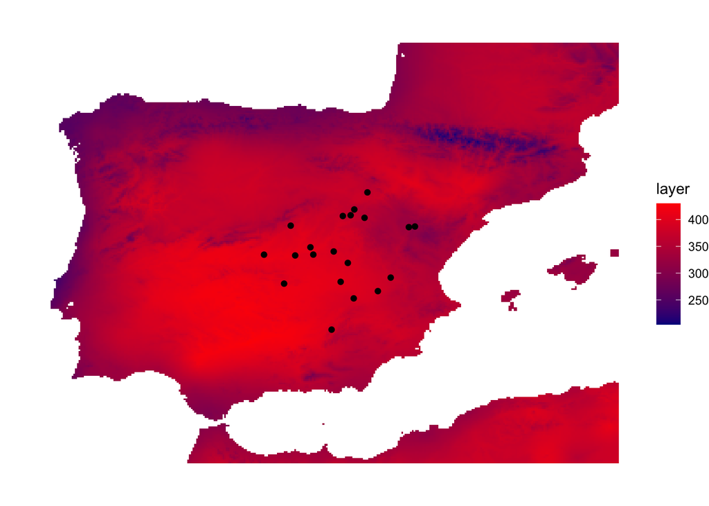

```r
ggplot() + geom_raster(data = tmax.df, aes(x = x, y = y, fill = layer)) + coord_equal() +
  geom_point(data = pts, aes(x = x, y = y)) + theme_void() + scale_fill_continuous(low="darkblue", high="red",
                       guide="colorbar",na.value="white")
```

# Leaflet

This is where it gets really interesting. Leaflet is a package that makes it very, very easy to make pretty, interactive maps. It includes built-in access to some very nice online tile sets, but it’s easy to throw your own data into it as well! There’s a fantastic online manual here:

(https://rstudio.github.io/leaflet/)

Now let’s map the location of my favorite tapas place.

```r
m <- leaflet()
m <- addTiles(m)

m <- addMarkers(m, lat = 41.3818491, lng = 2.182865, label = "Can Paixano")
m
```

[interactive chart not shown]

There’s more than one way to add text information to plots, though. Let’s try it as a “popup”.

```r
m <- leaflet()
m <- addTiles(m)
m <- addPopups(m, lat = 41.3818491, lng = 2.182865, popup = "Can Paixano")
m
```

[interactive chart not shown]

We can manually add circles wherever we want by passing a latitude and longitude, or vectors of latitudes and longitudes.

```r
corners.lat <- c(41.2, 41.2, 41.4, 41.4)
corners.lng = c(2.1, 2.2, 2.2, 2.1)
addCircles(m, corners.lng, corners.lat)
```

[interactive chart not shown]

Now let’s use these to draw a rectangle.

```r
addPolygons(m, corners.lng, corners.lat)
```

[interactive chart not shown]

Exercise: Can you make that into an hourglass shape?

We don’t have to build polygons manually, of course; we can just plot our existing shapefiles over our leaflet maps.

```r
m <- leaflet()
m <- addTiles(m)
m <- addPolygons(m, data = spain, color = "black", fillColor = heat.colors(14, alpha = NULL), weight = 1, opacity = 1)
m
```

[interactive chart not shown]

The default maps for Leaflet are nice, but you can also add tiles from other providers. There’s a list here:

(https://leaflet-extras.github.io/leaflet-providers/preview/)

```r
m <- leaflet()
m <- addProviderTiles(m, provider = "Stamen.Watercolor")
m
```

[interactive chart not shown]

And you can add custom icons!

```r
greenLeafIcon <- makeIcon(
  iconUrl = "http://leafletjs.com/examples/custom-icons/leaf-green.png",
  iconWidth = 38, iconHeight = 95,
  iconAnchorX = 22, iconAnchorY = 94,
  shadowUrl = "http://leafletjs.com/examples/custom-icons/leaf-shadow.png",
  shadowWidth = 50, shadowHeight = 64,
  shadowAnchorX = 4, shadowAnchorY = 62
)

m <- addMarkers(m, lat = 41.3818491, lng = 2.182865, label = "Can Paixano", icon = greenLeafIcon)

m
```

[interactive chart not shown]

One thing about leaflet is that it’s really intended for interactive maps. You can make a static map and render it to file, though, using the mapshot function in mapview.

```r
webshot::install_phantomjs()
```

```
## It seems that the version of `phantomjs` installed is greater than or equal to the requested version.To install the requested version or downgrade to another version, use `force = TRUE`.
```

```r
mapshot(m, file = "mymap.png")
mapshot(m, file = "mymap.pdf")
```

Or, if you’re in R Studio, you can plot your map in the viewer window and then use Export -> Save as Web Page to save the dynamic zoomable version to view in your web browser.

You can also add scale bars!

```r
m <- addScaleBar(m)
m
```

[interactive chart not shown]

And graticules! You may have to zoom out to see this one.

```r
m <- addSimpleGraticule(m, interval = 2)
m
```

[interactive chart not shown]

You can also add rasters to leaflet maps.

```r
m <- leaflet()
m <- addProviderTiles(m, provider = "Stamen.Toner")
m <- addRasterImage(m, env[[8]], opacity = 0.6)
m
```

[interactive chart not shown]

Let’s do that again but define our own color ramp and add a legend.

```r
m <- leaflet()
m <- addProviderTiles(m, provider = "Stamen.Toner")
pal <- colorNumeric(c("#0000FF", "#FFFFCC", "#FF0000"), values(env[[8]]),
  na.color = "transparent")
m <- addRasterImage(m, colors = pal, env[[8]], opacity = 0.6)
m <- addLegend(m, pal = pal, values = values(env[[8]]),
    title = "Surface temp")
m
```

[interactive chart not shown]

Now let’s do it without the background map, but with labels for places using provider tiles!

```r
m <- leaflet()
pal <- colorNumeric(c("#0000FF", "#FFFFCC", "#FF0000"), values(env[[8]]),
  na.color = "transparent")
m <- addRasterImage(m, colors = pal, env[[8]], opacity = 1)
m <- addLegend(m, pal = pal, values = values(env[[8]]),
    title = "Surface temp")
m <- addProviderTiles(m, provider = "CartoDB.PositronOnlyLabels")
m
```

[interactive chart not shown]

Now let’s just play around and make something pretty.

```r
m <- leaflet(spain)
m <- addProviderTiles(m, provider = "NASAGIBS.ViirsEarthAtNight2012")
m <- addProviderTiles(m, provider = "OpenRailwayMap")
m
```

[interactive chart not shown]

# Spatial data manipulation

Let’s get some data from Worldclim and crop it using our extent object for Spain. Then we’ll plot it using a cool trick in the addCircleMarkers function that lets us group points that are too close together to display well.

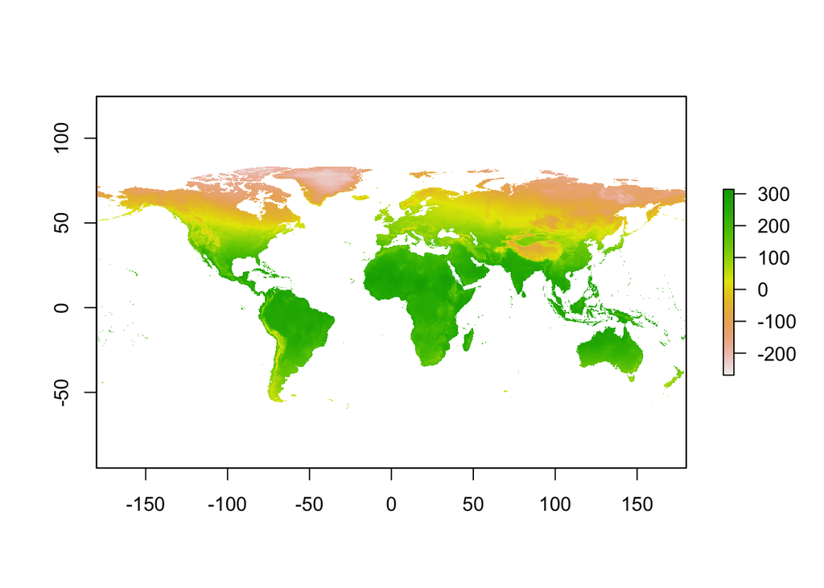

```r
all.worldclim <- raster::getData("worldclim", res = 10, var = "bio")
plot(all.worldclim[["bio1"]])
```

```r
spain.worldclim <- crop(all.worldclim, spain.extent)

m <- leaflet(pts)
m <- addProviderTiles(m, provider = "Stamen.Toner")
m <- addRasterImage(m, spain.worldclim[["bio1"]], opacity = 0.6)
m <- addCircleMarkers(m, lng = ~x, lat = ~y, clusterOptions = leaflet::markerClusterOptions())
m
```

[interactive chart not shown]

While we’re at it, I’ll point out that you can use the %>% operator from dplyr with leaflet to make your code prettier. Since the %>% operator automatically funnels the output from the previous function to the first argument of the input function, you can eliminate all of the “m” arguments.

```r
library(dplyr)
```

```r
m <- leaflet(pts) %>%
  addProviderTiles(provider = "Stamen.Toner") %>%
  addRasterImage(spain.worldclim[["bio1"]], opacity = 0.6) %>%
  addCircleMarkers(lng = ~x, lat = ~y, clusterOptions = leaflet::markerClusterOptions())

m
```

[interactive chart not shown]

What if we want the environmental data from our worldclim layer at each of our point locations?

```r
env.points <- extract(spain.worldclim, pts)
env.points
```

```
##       bio1 bio2 bio3 bio4 bio5 bio6 bio7 bio8 bio9 bio10 bio11 bio12 bio13
##  [1,]  110  110   38 6216  272  -17  289  132  191   192    34   469    64
##  [2,]  102  113   37 6380  274  -24  298  122  187   188    25   514    66
##  [3,]  148  113   35 6837  330   16  314  103  239   239    64   402    46
##  [4,]  122  118   37 6630  304   -7  311  106  211   212    43   479    56
##  [5,]   95  113   38 6280  265  -31  296  115  179   179    20   543    70
##  [6,]   91   96   36 6125  238  -27  265  109   18   173    18   549    76
##  [7,]  133  102   34 6573  302   10  292   90  221   221    52   449    57
##  [8,]  138  113   36 6713  318    9  309   95  228   228    57   427    51
##  [9,]   91   96   36 6125  238  -27  265  109   18   173    18   549    76
## [10,]  149  114   36 6764  331   17  314  134  240   240    66   377    44
## [11,]  137  120   38 6577  321    7  314  117  226   226    59   471    60
## [12,]  140  125   37 6868  334    4  330  123  232   232    57   440    52
## [13,]  125  123   38 6596  309   -8  317  108  212   213    45   484    58
## [14,]  142  118   39 6266  311   12  299  159  225   225    66   391    49
```

[output cut: 27 more lines]

```r
# We can also attach that to our lat/lon data

env.points <- cbind(pts, env.points)
env.points
```

```
##             x        y bio1 bio2 bio3 bio4 bio5 bio6 bio7 bio8 bio9 bio10 bio11
## 1  -1.9724565 41.44130  110  110   38 6216  272  -17  289  132  191   192    34
## 2  -2.3711902 40.89721  102  113   37 6380  274  -24  298  122  187   188    25
## 3  -3.6882062 39.94185  148  113   35 6837  330   16  314  103  239   239    64
## 4  -2.7733405 40.03619  122  118   37 6630  304   -7  311  106  211   212    43
## 5  -2.2846948 41.03518   95  113   38 6280  265  -31  296  115  179   179    20
## 6  -0.8437398 40.62992   91   96   36 6125  238  -27  265  109   18   173    18
## 7  -3.7945856 40.64946  133  102   34 6573  302   10  292   90  221   221    52
## 8  -3.3263259 40.13643  138  113   36 6713  318    9  309   95  228   228    57
## 9  -0.9886824 40.61501   91   96   36 6125  238  -27  265  109   18   173    18
## 10 -4.4284524 39.96001  149  114   36 6764  331   17  314  134  240   240    66
## 11 -2.8236313 38.17799  137  120   38 6577  321    7  314  117  226   226    59
## 12 -3.9516072 39.27146  140  125   37 6868  334    4  330  123  232   232    57
## 13 -2.4382729 39.76418  125  123   38 6596  309   -8  317  108  212   213    45
## 14 -1.7243321 39.09374  142  118   39 6266  311   12  299  159  225   225    66
```

[output cut: 27 more lines]

Let’s see how our fake species’ environmental distribution differs from the suite of available habitats. We’ll need some points randomely chosen from the background.

```r
bg.pts <- sampleRandom(spain.worldclim, xy = TRUE, size = 1000)
head(bg.pts)
```

```
##               x        y bio1 bio2 bio3 bio4 bio5 bio6 bio7 bio8 bio9 bio10
## [1,] -4.4166667 42.91667   84   96   39 5039  225  -20  245   60  151   151
## [2,] -1.2500000 42.91667   89   98   39 5316  228  -19  247   32  159   159
## [3,] -0.9166667 42.75000   89   99   39 5395  229  -22  251   31  160   160
## [4,] -5.2500000 37.25000  174  113   40 5830  336   55  281  111  250   251
## [5,] -1.5833333 37.58333  159  109   40 5639  308   37  271  130  233   235
## [6,] -3.9166667 39.08333  146  128   38 6850  342    9  333  130  239   239
##      bio11 bio12 bio13 bio14 bio15 bio16 bio17 bio18 bio19
## [1,]    23   860   100    44    22   275   157   157   232
## [2,]    23  1096   124    59    18   333   211   211   314
## [3,]    22   952   101    52    16   274   190   190   257
## [4,]   103   647   101     1    66   283    17    23   268
## [5,]    91   345    47     5    42   122    31    40    96
## [6,]    63   423    51     4    43   147    36    36   126
```

Notice how this got us our x and y as well as our environmental data? Pretty slick.

```r
bg.pts <- as.data.frame(bg.pts)
m <- leaflet(bg.pts) %>%
  addProviderTiles(provider = "Stamen.Toner") %>%
  addRasterImage(spain.worldclim[[1]], opacity = 0.6) %>%
  addCircleMarkers(lng = ~x, lat = ~y, clusterOptions = leaflet::markerClusterOptions())

m
```

[interactive chart not shown]

Okay, let’s combine our presence points and our background points. First let’s make a presence/absence variable.

```r
pa <- c(rep(1, nrow(env.points)), rep(0, nrow(bg.pts)))

pa
```

```
##    [1] 1 1 1 1 1 1 1 1 1 1 1 1 1 1 1 1 1 1 1 1 0 0 0 0 0 0 0 0 0 0 0 0 0 0 0 0 0
##   [38] 0 0 0 0 0 0 0 0 0 0 0 0 0 0 0 0 0 0 0 0 0 0 0 0 0 0 0 0 0 0 0 0 0 0 0 0 0
##   [75] 0 0 0 0 0 0 0 0 0 0 0 0 0 0 0 0 0 0 0 0 0 0 0 0 0 0 0 0 0 0 0 0 0 0 0 0 0
##  [112] 0 0 0 0 0 0 0 0 0 0 0 0 0 0 0 0 0 0 0 0 0 0 0 0 0 0 0 0 0 0 0 0 0 0 0 0 0
##  [149] 0 0 0 0 0 0 0 0 0 0 0 0 0 0 0 0 0 0 0 0 0 0 0 0 0 0 0 0 0 0 0 0 0 0 0 0 0
##  [186] 0 0 0 0 0 0 0 0 0 0 0 0 0 0 0 0 0 0 0 0 0 0 0 0 0 0 0 0 0 0 0 0 0 0 0 0 0
##  [223] 0 0 0 0 0 0 0 0 0 0 0 0 0 0 0 0 0 0 0 0 0 0 0 0 0 0 0 0 0 0 0 0 0 0 0 0 0
##  [260] 0 0 0 0 0 0 0 0 0 0 0 0 0 0 0 0 0 0 0 0 0 0 0 0 0 0 0 0 0 0 0 0 0 0 0 0 0
##  [297] 0 0 0 0 0 0 0 0 0 0 0 0 0 0 0 0 0 0 0 0 0 0 0 0 0 0 0 0 0 0 0 0 0 0 0 0 0
##  [334] 0 0 0 0 0 0 0 0 0 0 0 0 0 0 0 0 0 0 0 0 0 0 0 0 0 0 0 0 0 0 0 0 0 0 0 0 0
##  [371] 0 0 0 0 0 0 0 0 0 0 0 0 0 0 0 0 0 0 0 0 0 0 0 0 0 0 0 0 0 0 0 0 0 0 0 0 0
##  [408] 0 0 0 0 0 0 0 0 0 0 0 0 0 0 0 0 0 0 0 0 0 0 0 0 0 0 0 0 0 0 0 0 0 0 0 0 0
##  [445] 0 0 0 0 0 0 0 0 0 0 0 0 0 0 0 0 0 0 0 0 0 0 0 0 0 0 0 0 0 0 0 0 0 0 0 0 0
##  [482] 0 0 0 0 0 0 0 0 0 0 0 0 0 0 0 0 0 0 0 0 0 0 0 0 0 0 0 0 0 0 0 0 0 0 0 0 0
##  [519] 0 0 0 0 0 0 0 0 0 0 0 0 0 0 0 0 0 0 0 0 0 0 0 0 0 0 0 0 0 0 0 0 0 0 0 0 0
##  [556] 0 0 0 0 0 0 0 0 0 0 0 0 0 0 0 0 0 0 0 0 0 0 0 0 0 0 0 0 0 0 0 0 0 0 0 0 0
##  [593] 0 0 0 0 0 0 0 0 0 0 0 0 0 0 0 0 0 0 0 0 0 0 0 0 0 0 0 0 0 0 0 0 0 0 0 0 0
##  [630] 0 0 0 0 0 0 0 0 0 0 0 0 0 0 0 0 0 0 0 0 0 0 0 0 0 0 0 0 0 0 0 0 0 0 0 0 0
##  [667] 0 0 0 0 0 0 0 0 0 0 0 0 0 0 0 0 0 0 0 0 0 0 0 0 0 0 0 0 0 0 0 0 0 0 0 0 0
##  [704] 0 0 0 0 0 0 0 0 0 0 0 0 0 0 0 0 0 0 0 0 0 0 0 0 0 0 0 0 0 0 0 0 0 0 0 0 0
##  [741] 0 0 0 0 0 0 0 0 0 0 0 0 0 0 0 0 0 0 0 0 0 0 0 0 0 0 0 0 0 0 0 0 0 0 0 0 0
##  [778] 0 0 0 0 0 0 0 0 0 0 0 0 0 0 0 0 0 0 0 0 0 0 0 0 0 0 0 0 0 0 0 0 0 0 0 0 0
##  [815] 0 0 0 0 0 0 0 0 0 0 0 0 0 0 0 0 0 0 0 0 0 0 0 0 0 0 0 0 0 0 0 0 0 0 0 0 0
##  [852] 0 0 0 0 0 0 0 0 0 0 0 0 0 0 0 0 0 0 0 0 0 0 0 0 0 0 0 0 0 0 0 0 0 0 0 0 0
##  [889] 0 0 0 0 0 0 0 0 0 0 0 0 0 0 0 0 0 0 0 0 0 0 0 0 0 0 0 0 0 0 0 0 0 0 0 0 0
##  [926] 0 0 0 0 0 0 0 0 0 0 0 0 0 0 0 0 0 0 0 0 0 0 0 0 0 0 0 0 0 0 0 0 0 0 0 0 0
##  [963] 0 0 0 0 0 0 0 0 0 0 0 0 0 0 0 0 0 0 0 0 0 0 0 0 0 0 0 0 0 0 0 0 0 0 0 0 0
## [1000] 0 0 0 0 0 0 0 0 0 0 0 0 0 0 0 0 0 0 0 0 0
```

Now we’ll attach it to our data.

```r
pa.env.points <- rbind(env.points, bg.pts)
pa.env.points <- cbind(pa.env.points, pa)
pa.env.points <- data.frame(pa.env.points)
head(pa.env.points)
```

```
##            x        y bio1 bio2 bio3 bio4 bio5 bio6 bio7 bio8 bio9 bio10 bio11
## 1 -1.9724565 41.44130  110  110   38 6216  272  -17  289  132  191   192    34
## 2 -2.3711902 40.89721  102  113   37 6380  274  -24  298  122  187   188    25
## 3 -3.6882062 39.94185  148  113   35 6837  330   16  314  103  239   239    64
## 4 -2.7733405 40.03619  122  118   37 6630  304   -7  311  106  211   212    43
## 5 -2.2846948 41.03518   95  113   38 6280  265  -31  296  115  179   179    20
## 6 -0.8437398 40.62992   91   96   36 6125  238  -27  265  109   18   173    18
##   bio12 bio13 bio14 bio15 bio16 bio17 bio18 bio19 pa
## 1   469    64    25    26   157    93   105   105  1
## 2   514    66    24    25   163    92   100   122  1
## 3   402    46     8    37   135    43    43   116  1
## 4   479    56    15    30   152    68    70   125  1
## 5   543    70    28    24   175   103   114   127  1
## 6   549    76    29    30   191    97   137    97  1
```

Let’s plot where we find our species vs. the available environment. Try visualizing several different environmental variables.

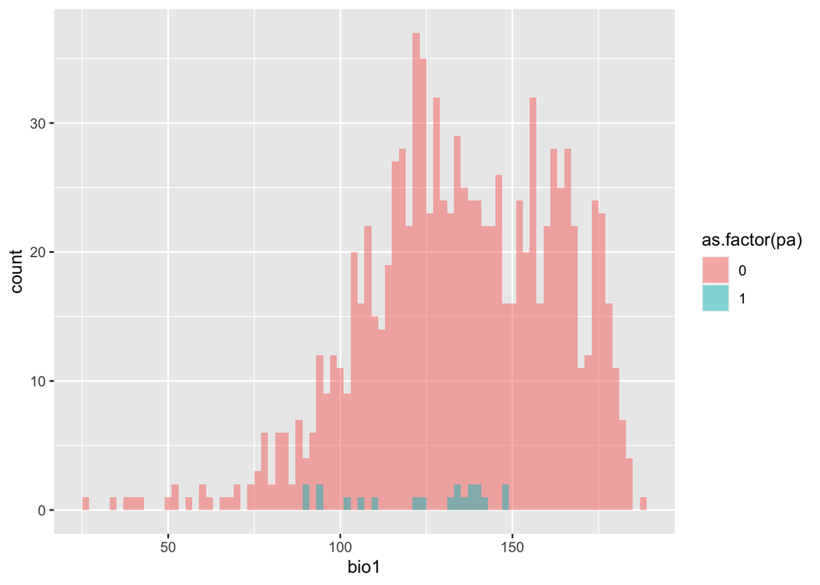

```r
ggplot(pa.env.points, aes(x=bio1, fill=as.factor(pa))) + geom_histogram(binwidth=2, alpha=.5, position="identity")
```

Let’s try something different now - can we get a localized convex hull range map for our species? We can, with the adehabitatHR package!

```r
library(adehabitatHR)
```

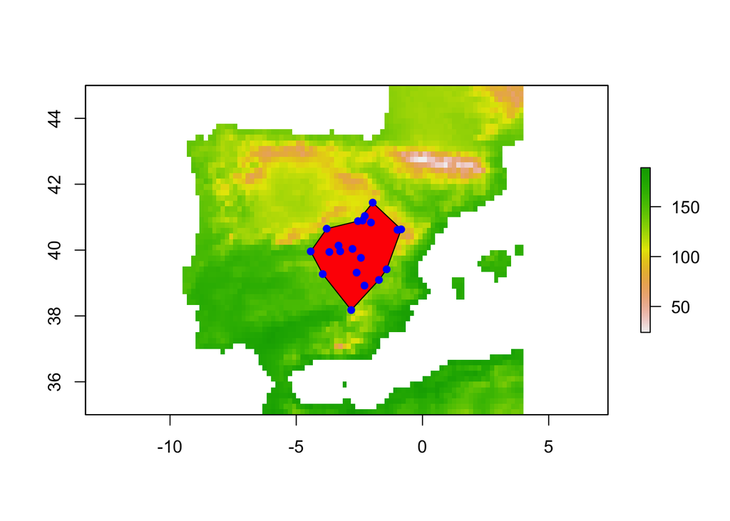

```r
pts.locoh <- LoCoH.k(SpatialPoints(pts), k = 8)
pts.locoh.dissolved <- unionSpatialPolygons(pts.locoh, IDs = rep(1, length(pts.locoh)))
plot(spain.worldclim[["bio1"]])
plot(pts.locoh.dissolved, add = TRUE, col = "red")
points(pts, col = "blue", pch = 16)
```

```r
m <- leaflet(pts.locoh.dissolved) %>%
  addProviderTiles(provider = "Stamen.Toner") %>%
  addRasterImage(spain.worldclim[[1]], opacity = 0.6) %>%
  addPolygons()

m
```

[interactive chart not shown]

Can we repeat the exercise above where we’re comparing species’ environmental distributions to the available environment, but use the convex hull instead of the raster for our background data? It takes a bit more work, but we can.

```r
hull.pts <- spsample(pts.locoh.dissolved, n = 1000, type = "random")
class(hull.pts)
```

```
## [1] "SpatialPoints"
## attr(,"package")
## [1] "sp"
```

This hull.pts is a SpatialPoints object stores its lats and longs inside of the object in a data frame you access using @coords

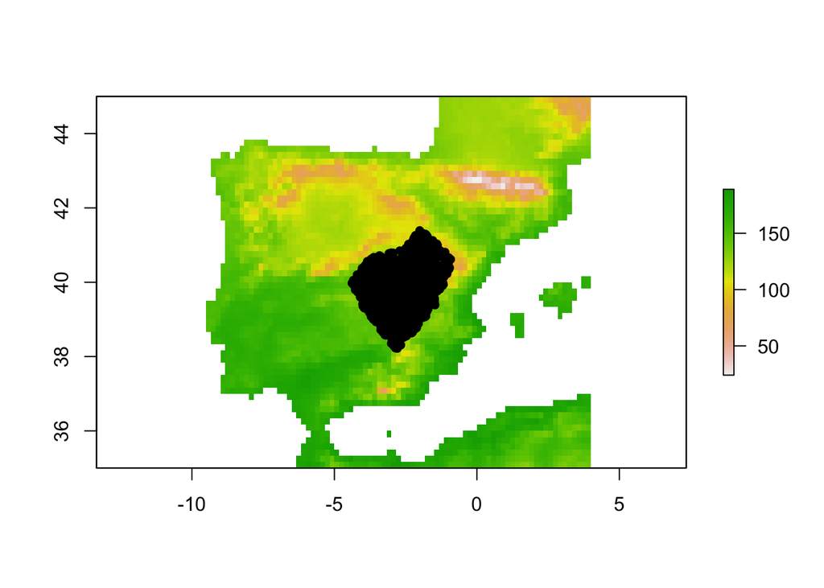

```r
plot(spain.worldclim[[1]])
points(hull.pts@coords, pch = 16)
```

Now we’ll extract our environmental data for our new background points.

```r
hull.env <- cbind(hull.pts@coords, extract(spain.worldclim, hull.pts@coords))
head(hull.env)
```

```
##              x        y bio1 bio2 bio3 bio4 bio5 bio6 bio7 bio8 bio9 bio10
## [1,] -1.875540 40.06127   99  118   38 6460  276  -30  306   81  185   186
## [2,] -1.916409 40.65803   85  112   37 6337  254  -41  295  104  170   171
## [3,] -2.247681 40.32990  111  121   38 6495  292  -20  312   95  198   199
## [4,] -3.115643 39.09880  143  123   38 6706  332    9  323  126  234   234
## [5,] -3.026067 39.35039  141  122   38 6729  328    7  321  125  232   232
## [6,] -4.333822 40.05394  149  112   36 6700  328   18  310  106  239   239
##      bio11 bio12 bio13 bio14 bio15 bio16 bio17 bio18 bio19
## [1,]    22   568    73    25    26   186   101   112   128
## [2,]    10   594    79    31    25   197   116   130   129
## [3,]    33   521    66    20    27   170    85    92   126
## [4,]    62   425    51     7    38   146    45    45   119
## [5,]    60   421    48     8    36   140    47    47   116
## [6,]    67   366    43     8    37   120    41    41   100
```

Then we’ll repeat the steps above to visualize presence and background. We’ll just rebuild the env.points data frame since it’s got the other pa data in it.

```r
env.points <- cbind(pts, extract(spain.worldclim, pts))
hull.pa <- c(rep(1, nrow(env.points)), rep(0, nrow(hull.env)))
hull.pa.env <- rbind(env.points, hull.env)
hull.pa.env <- cbind(hull.pa.env, hull.pa)
head(hull.pa.env)
```

```
##            x        y bio1 bio2 bio3 bio4 bio5 bio6 bio7 bio8 bio9 bio10 bio11
## 1 -1.9724565 41.44130  110  110   38 6216  272  -17  289  132  191   192    34
## 2 -2.3711902 40.89721  102  113   37 6380  274  -24  298  122  187   188    25
## 3 -3.6882062 39.94185  148  113   35 6837  330   16  314  103  239   239    64
## 4 -2.7733405 40.03619  122  118   37 6630  304   -7  311  106  211   212    43
## 5 -2.2846948 41.03518   95  113   38 6280  265  -31  296  115  179   179    20
## 6 -0.8437398 40.62992   91   96   36 6125  238  -27  265  109   18   173    18
##   bio12 bio13 bio14 bio15 bio16 bio17 bio18 bio19 hull.pa
## 1   469    64    25    26   157    93   105   105       1
## 2   514    66    24    25   163    92   100   122       1
## 3   402    46     8    37   135    43    43   116       1
## 4   479    56    15    30   152    68    70   125       1
## 5   543    70    28    24   175   103   114   127       1
## 6   549    76    29    30   191    97   137    97       1
```

And now to plot! Note that ggplot likes data frames, not matrices, so we have to convert first.

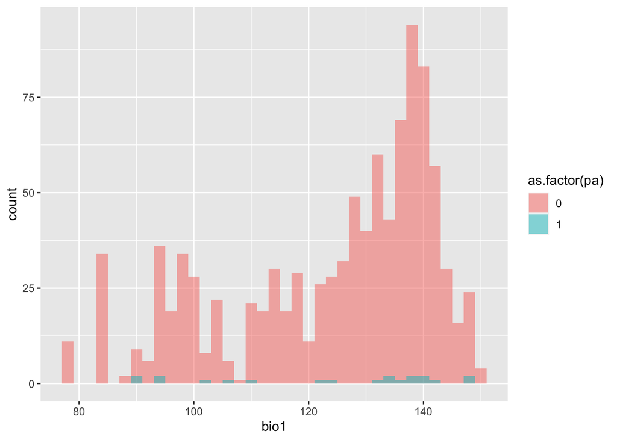

```r
hull.pa.env <- data.frame(hull.pa.env)
ggplot(hull.pa.env, aes(x=bio1, fill=as.factor(pa))) + geom_histogram(binwidth=2, alpha=.5, position="identity")
```